# Jacob Neural Net Final Projects

## Libraries:

```r
library(tidyverse) # data manipulation
library(neuralnet)# neural net library
library(gridExtra) # for plot function
library(grid) # for plot function
source('jacob_multiplots.R')
#library(tidyverse) # data manipulation
library(made4) #data package
#library(neuralnet)# neural net library
#library(e1071) # SVM
#library(gridExtra) # for plot function
#library(grid) # for plot function
data(khan)
```

## Functions:

Below are a bunch of functions I made to conduct cross validation easily and could help with the SVM training.

```r
# I moved all my functions into an R script to be used by other scripts too!
source(neural_net_functions.R)
```

[output not shown]

## Data import:

```r
# Read in the cleaned expression data
expression <- as.data.frame((read.table("../data/clean_expression.txt", row.names=1 )))
rownames(expression)[1] <- '184A1'# Rename the only integer name
# Read in the subtype data
subtypes <- read_tsv("../data/clean_subtypes.txt")
# Read in the truth set
truth_set <-  as.data.frame((read.table("../data/clean_training_answers.txt", row.names=1 )))
# Create merged feature set
featureSet<-cbind(subtypes[,2],t(expression))
dim(expression)
```

```
[1] 18632    25
```

```r
dim(subtypes)
```

```
[1] 25  2
```

```r
dim(truth_set)
```

```
[1] 25 12
```

```r
dim(featureSet)
```

```
[1]    25 18633
```

## EDA:

Now looking for missings values

```r
apply(khan$train, 2, function(x) sum(is.na(x)))
```

```
 EWS.T1  EWS.T2  EWS.T3  EWS.T4  EWS.T6  EWS.T7  EWS.T9 EWS.T11 EWS.T12 EWS.T13 EWS.T14 EWS.T15 EWS.T19  EWS.C8
      0       0       0       0       0       0       0       0       0       0       0       0       0       0
 EWS.C3  EWS.C2  EWS.C4  EWS.C6  EWS.C9  EWS.C7  EWS.C1 EWS.C11 EWS.C10   BL.C5   BL.C6   BL.C7   BL.C8   BL.C1
      0       0       0       0       0       0       0       0       0       0       0       0       0       0
  BL.C2   BL.C3   BL.C4   NB.C1   NB.C2   NB.C3   NB.C6  NB.C12   NB.C7   NB.C4   NB.C5  NB.C10  NB.C11   NB.C9
      0       0       0       0       0       0       0       0       0       0       0       0       0       0
  NB.C8  RMS.C4  RMS.C3  RMS.C9  RMS.C2  RMS.C5  RMS.C6  RMS.C7  RMS.C8 RMS.C10 RMS.C11  RMS.T1  RMS.T4  RMS.T2
      0       0       0       0       0       0       0       0       0       0       0       0       0       0
 RMS.T6  RMS.T7  RMS.T8  RMS.T5  RMS.T9  RMS.T3 RMS.T10 RMS.T11
      0       0       0       0       0       0       0       0
```

```r
apply(khan$test, 2, function(x) sum(is.na(x)))
```

```
 TEST.9 TEST.11  TEST.5  TEST.8 TEST.10 TEST.13  TEST.3  TEST.1  TEST.2  TEST.4  TEST.7 TEST.12 TEST.24  TEST.6
      0       0       0       0       0       0       0       0       0       0       0       0       0       0
TEST.21 TEST.20 TEST.17 TEST.18 TEST.22 TEST.16 TEST.23 TEST.14 TEST.25 TEST.15 TEST.19
      0       0       0       0       0       0       0       0       0       0       0
```

```r
summary(khan$train.classes)
```

```
   EWS BL-NHL     NB    RMS
    23      8     12     21
```

```r
summary(khan$test.classes)
```

```
   EWS BL-NHL     NB    RMS Normal
     6      3      6      5      5
```

2. [30 points] Using the “neuralnet” package in R, implement a neural network that will distinguish between RMS sample and EWS samples. This network should have an input node for each of the gene expression values, one hidden layer and one output node. You decide on how many hidden nodes to use and the learning rate. Experimentation is encouraged and a rationale for your choices is required.

Subseting the data

I only want the data that correspond to the two classes I am interested in (RMS, EWS).

```r
#Subset trainingdata
# Transpose dataset to Feature Set (so each column is a feature)
train <- data.frame(t(khan$train))
# Make Vector of the truth_set
classif <- khan$train.classes
# Append Truthset to Feature set
ktrain <- data.frame(cbind(classif,train))
# Now scale the data ( IN this case KIND OF SCALING GOES HERE)
ktrain <- scale_data(ktrain)
# Now convert the truthset into factors outputing vector.
E.Ws <- c('EWS','RMS')
E.W <- ktrain$classif %in% E.Ws
# Mask the truthset into integers instead of strings.
# CONSIDER BINARY MASK OR MASKING ALL FEATURES
ktrain <- ktrain[E.W,]
ktrain <- E_recode(ktrain)
# Now look at it!
dim(ktrain)
```

```
[1]  44 307
```

```r
head(ktrain[,1:5])
```

|  | classif | X25725 | X193913 | X725454 | X297392 |
| --- | --- | --- | --- | --- | --- |
| EWS.T1 | 1 | 0.009971738 | 0.13600133 | 0.2318599 | 0.10878184 |
| EWS.T2 | 1 | 0.011518157 | 0.09618897 | 0.4409300 | 0.06661055 |
| EWS.T3 | 1 | 0.035514318 | 0.08668217 | 0.1028129 | 0.05384782 |
| EWS.T4 | 1 | 0.075294620 | 0.08045500 | 0.4983352 | 0.89002335 |
| EWS.T6 | 1 | 0.099877353 | 0.14019429 | 0.2664179 | 0.18514093 |
| EWS.T7 | 1 | 0.017543860 | 0.13305380 | 0.1220436 | 0.07424103 |

```r
#Subset Testing Data
# Same thing
test <- data.frame(t(khan$test))
classif <- khan$test.classes
ktest <- data.frame(cbind(classif,test))
ktest <- scale_data(ktest)
E.W <- ktest$classif %in% E.Ws
ktest <- ktest[E.W,]
ktest <- E_recode(ktest)
dim(ktest)
```

```
[1]  11 307
```

```r
head(ktest[,1:5])
```

|  | classif | X25725 | X193913 | X725454 | X297392 |
| --- | --- | --- | --- | --- | --- |
| TEST.10 | 0 | 0.17115323 | 0.06902812 | 0.04222531 | 0.49530657 |
| TEST.2 | 1 | 0.03103116 | 0.00000000 | 0.26047203 | 0.22162256 |
| TEST.4 | 0 | 0.77449406 | 0.01646024 | 0.26796906 | 0.02122164 |
| TEST.12 | 1 | 0.05711532 | 0.14911042 | 0.18462912 | 0.18650373 |
| TEST.24 | 0 | 0.23938323 | 0.12385525 | 0.24916700 | 0.23033480 |
| TEST.6 | 1 | 0.03912624 | 0.15794570 | 0.08750496 | 0.09492878 |

Now I will proceed to only touch the testing data only when I am fully testing a cross-validated model.

```r
set.seed(2019) #set the seed
n <- names(ktrain) #extract names to build formula
f <- as.formula(paste('classif ~', paste(n[!n %in% 'classif'], collapse = ' + ')))
k_indexs <- sample(seq(nrow(ktrain))) #scamble the indexs in order to conduct k-fold
nss <- c(1,2,3,4,5,10,20,40,45) # range of hidden layer nodes to explore
ls <- c(.1,.2,.3,.4,.5,.6,.7,.8,.9,1) # range of learning rates to explore
ls_len <- length(ls) # length of the learning rate, i made it same as nodes
zero_ls <- rep(0,ls_len) # empty zero vector to make R happy
train.acc.mat <- data.frame(zero_ls) #initalize to empty vector to make the raw matrix
test.acc.mat <- data.frame(zero_ls) # ^^^
# Node amount loop (outter most loop)
for (s in seq(length(nss))){

  ns <- nss[s] #extract node number


  train.acc <- zero_ls # inilize the accuracy vectors
  test.acc <- zero_ls  # ^^^

  # Learning Rate Loop (middle loop)
  for (l in seq(ls_len)){
    lss <- ls[l] #extract the learning rate

    # Cross validation loop
    for (i in seq(11)) {

        if (i == 1){
          str <- 1 # initalize start index
          stp <- 4 # initialize stop index
        }
        else{
          #4 fold cross validation I chose this way bc the math was easier
          str <- str + 4
          stp <- stp + 4
        }

      k_in <- k_indexs[str:stp] #Pull out the indexs from the shuffled vector

      # Subsetting the trianing data
      fold_cross <- ktrain[k_in,] # Cross validation test set
      fold_c_truth <- ktrain[k_in,1] # Cross validation test truth
      fold_train <- ktrain[-k_in,] # Cross-V training data
      fold_t_truth <- ktrain[-k_in,1] # Cross-V training truth

      #Note: The ns can be made into multiple layers by c(layer1,layer2)

      # Do the THING!
      nn <- neuralnet(f,data=fold_train, hidden=ns, learningrate = lss, linear.output = F)


      # compute train predictions
      train.pr <- neuralnet::compute(nn,fold_train[,2:ncol(fold_train)])
      train_result <- round(train.pr$net.result)

      # find train accuracy and append to vector
      train.a <- perc_acc(train_result, fold_t_truth,11) #11 cross validation loop ave
      train.acc[l] <- train.acc[l] + train.a

      #compute test preditctions
      test.pr <- neuralnet::compute(nn,fold_cross[,2:ncol(fold_cross)])
      test_result <- round(test.pr$net.result)

      #find test accuracy and append to vector
      test.a <- perc_acc(test_result,fold_c_truth,11) #11 cross validation loop ave
      test.acc[l] <- test.acc[l] + test.a


  }
  }
  # add the accuracy vectors to their matrixes
  train.acc.mat <- cbind(train.acc.mat,train.acc)
  test.acc.mat <- cbind(test.acc.mat,test.acc)
}
train.acc.mat <- train.acc.mat[,2:ncol(train.acc.mat)]
test.acc.mat <- test.acc.mat[,2:ncol(test.acc.mat)]
```

Now that I have the training and test matrixes it is time to merge them into one for easy plotting

```r
#Now merging into one matrix
organized_matrix <- data.frame(learning_rate = ls)
# Now append the matrixes in order as they appear with node amount.
# Train and Test accuracy ae side by side.
n <- length(train.acc.mat)
for (i in seq(n)){
  buffer <- data.frame(train.acc.mat[i],test.acc.mat[i])
  nodes <- as.character(nss[i])
  #print(nodes)
  updated_names <- c(paste('train_nodes_',nodes,sep=''),paste('test_nodes_',nodes,sep = ''))

  colnames(buffer) <- updated_names

  organized_matrix <-  cbind(organized_matrix, buffer)
}
#Now clean names
organized_matrix
```

| learning_rate | train_nodes_1 | test_nodes_1 | train_nodes_2 | test_nodes_2 | train_nodes_3 | test_nodes_3 | train_nodes_4 | test_nodes_4 | train_nodes_5 | test_nodes_5 | train_nodes_10 | test_nodes_10 | train_nodes_20 | test_nodes_20 | train_nodes_40 | test_nodes_40 | train_nodes_45 | test_nodes_45 |
| --- | --- | --- | --- | --- | --- | --- | --- | --- | --- | --- | --- | --- | --- | --- | --- | --- | --- | --- |
| 0.1 | 0.9590909 | 0.9090909 | 1 | 0.9772727 | 1 | 0.9772727 | 1 | 0.9772727 | 1 | 0.9772727 | 1 | 0.9772727 | 1 | 0.9545455 | 0.9159091 | 0.8409091 | 0.8636364 | 0.8181818 |
| 0.2 | 1.0000000 | 0.9772727 | 1 | 0.9772727 | 1 | 0.9772727 | 1 | 0.9772727 | 1 | 1.0000000 | 1 | 1.0000000 | 1 | 1.0000000 | 0.8272727 | 0.7500000 | 0.8659091 | 0.8181818 |
| 0.3 | 1.0000000 | 0.9772727 | 1 | 0.9772727 | 1 | 1.0000000 | 1 | 0.9772727 | 1 | 0.9772727 | 1 | 0.9772727 | 1 | 0.9772727 | 0.9568182 | 0.9318182 | 0.7590909 | 0.8181818 |
| 0.4 | 0.9590909 | 0.9090909 | 1 | 1.0000000 | 1 | 1.0000000 | 1 | 0.9772727 | 1 | 1.0000000 | 1 | 0.9545455 | 1 | 0.9772727 | 0.9136364 | 0.8181818 | 0.7772727 | 0.6818182 |
| 0.5 | 0.9613636 | 0.9090909 | 1 | 0.9772727 | 1 | 0.9772727 | 1 | 0.9772727 | 1 | 0.9545455 | 1 | 0.9545455 | 1 | 0.9545455 | 0.8568182 | 0.8636364 | 0.7659091 | 0.7500000 |
| 0.6 | 1.0000000 | 0.9772727 | 1 | 0.9772727 | 1 | 0.9772727 | 1 | 1.0000000 | 1 | 0.9772727 | 1 | 0.9772727 | 1 | 0.9772727 | 0.8204545 | 0.8863636 | 0.8181818 | 0.7954545 |
| 0.7 | 1.0000000 | 0.9772727 | 1 | 1.0000000 | 1 | 0.9772727 | 1 | 0.9772727 | 1 | 0.9772727 | 1 | 0.9772727 | 1 | 0.9772727 | 0.7363636 | 0.5681818 | 0.8318182 | 0.7727273 |
| 0.8 | 0.9568182 | 0.9318182 | 1 | 0.9772727 | 1 | 0.9772727 | 1 | 0.9772727 | 1 | 0.9772727 | 1 | 0.9772727 | 1 | 0.9772727 | 0.8568182 | 0.8409091 | 0.7227273 | 0.7727273 |
| 0.9 | 1.0000000 | 1.0000000 | 1 | 0.9772727 | 1 | 0.9772727 | 1 | 1.0000000 | 1 | 0.9772727 | 1 | 1.0000000 | 1 | 0.9772727 | 0.8159091 | 0.7272727 | 0.8090909 | 0.8863636 |
| 1.0 | 1.0000000 | 0.9772727 | 1 | 0.9772727 | 1 | 0.9772727 | 1 | 0.9772727 | 1 | 0.9772727 | 1 | 0.9772727 | 1 | 0.9772727 | 0.8227273 | 0.7727273 | 0.9090909 | 0.9090909 |

Now lets make some plots

first and foremost I found some code that plots a common legend on the ggplot2 github: [link](https://github.com/tidyverse/ggplot2/wiki/Share-a-legend-between-two-ggplot2-graphs)

At the top I sourced the script

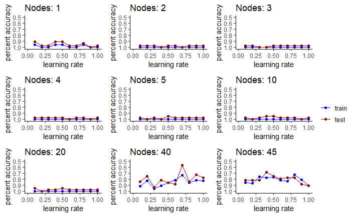

```r
names <- names(organized_matrix)
lr <- names[1] #SHOU<D BE 1 BUT I AM DEBUGGING!!!!!!!!!
# Modifying matrix to have the darn colors
train_ <- rep('train',length(organized_matrix[,2]))
test_<-  rep('test',length(organized_matrix[,3]))
colors  <- data.frame(train_,test_)
plot_organized_matrix <- cbind(colors,organized_matrix)
names <- names(plot_organized_matrix)
len_n <- length(names)
ggpls <- list()
for (i in seq(4,len_n,2)){
  train_n <- names[i]
  test_n <- names[i+1]

  nod <-  strsplit(train_n, split='_')[[1]][3]

  gorb <- ggplot(plot_organized_matrix) +
    geom_point(aes_string(x=lr, y=train_n, color = 'train_')) +
    geom_line(aes_string(x=lr, y=train_n,color = 'train_')) +
    geom_point(aes_string(x=lr, y=test_n, color = 'test_')) +
    geom_line(aes_string(x=lr, y=test_n, color = 'test_')) +
    xlim(0.01,1.01) + ylim(1.01,.50) +
    scale_color_manual('',
                       breaks= c('train','test'),
                       values = c('darkred','blue')) +
    #guides(color=FALSE) + # This hides the legends but i found a function that does it
    theme_classic() +
    xlab('learning rate') + ylab('percent accuracy') +
    labs(title=paste('Nodes:',nod))


  ggpls <- c(ggpls,list(gorb))
}


# Make list of grobs as output from the loop
grid_arrange_shared_legend(ggpls, ncol=3,nrow=3, position = 'right')
```

```r
print('Title: Percent accruacry for both training and test cross validation set')
```

```
[1] "Title: Percent accruacry for both training and test cross validation set"
```

Based on this output it is clear that a lower number of nodes offers greater accuracy. Lookat the high amount of nodes graphs it is clear these suck.

### OPTIMAL PARAMETERS:

nodes: 5

learning rate: .5

This feels right, it allows the test set to misclassify while also not being overfit to the training data. Additionally I wanted to stick to a lower node amount as we do not have enough observations.

But, lets find out!

3. [20 points] Examine the performance of your net on the test data. Did the net over-fit your training data? How can you tell? Can you tell from the model which genes have the largest influence on the classification (gene names are provided in the khan data object)?

using the optimal parameters found during cross-validation

[figure not shown]

```r
set.seed(2019)
n <- names(ktrain)
f <- as.formula(paste('classif ~', paste(n[!n %in% 'classif'], collapse = ' + ')))
nn <- neuralnet(f,data=ktrain, hidden=5, learningrate = .5, linear.output = F, algorithm = 'backprop')
plot(nn)
```

```r
# compute train predictions
train.pr <- neuralnet::compute(nn,ktrain[,2:ncol(ktrain)])
train_result <- round(train.pr$net.result)
# find train accuracy and append to vector
train.acc <- perc_acc(train_result, ktrain[,1])
  #compute test preditctions
test.pr <- neuralnet::compute(nn,ktest[,2:ncol(ktest)])
test_result <- round(test.pr$net.result)
#find test accuracy and append to vector
test.acc <- perc_acc(test_result,ktest[,1])
paste('training accuracy: ', train.acc)
```

```
[1] "training accuracy:  0.999999999999999"
```

```r
paste('test accuracy: ', test.acc)
```

```
[1] "test accuracy:  0.818181818181818"
```

Just using 5 nodes with a learing rate of .5 gives 81% accuracy on the testing data.

This makes me not trust this at all.

Neuralnets also offers greater interpretablility as you can see which weights offer the greatest influence on the model the greatest.